# Housing Market Change after Natural Disaster

**Team Members:** Brandon Butler and Sofia Della Rosa

**Website Link:** https://sofiadellarosa.github.io/FinalProjectDS/

## Project Goal and Description:

The goal of this project is to analyze how certain natural disasters in different regions impact the housing market in the United States. We can use that information to see if property values decline after disasters and how quickly they recover. The natural disasters we will be looking at are: hurricanes, earthquake, drought, fire, flood, and tornadoes.

## Research Questions:

1. How do different types of natural disasters impact housing prices in affected regions?
2. What is the average recovery time for property values to return to pre-disaster levels?

## Data Sources:

1. FEMA Disaster Declarations Summaries: Provides records of federally declared disasters in the U.S., included type, location, and date.
- This dataset is appropriate because it allows us to identify when and where natural disasters occurred, which is necessary for analyzing their impact on housing markets.
2. Federal Housing Finance Agency’s HPI: Shows yearly house price changes at the ZIP code level.
- This dataset is appropriate because it allows us to measure how home values have changed over time and across regions, which is important to understanding the economic effects of disasters.
3. US Zip Codes Database from SimpleMaps: Contains ZIP code to state mapping and geographic info from the USPS, Census Bureau, and other authoritative sources.
- This dataset is appropriate because it lets us connect housing data (by ZIP code) to state-level disaster data, making regional analysis possible.

## Collaboration Plan:

For this project, we have a collaboration plan to make sure we have efficient workflow and collaboration. We meet in person every Wednesday to work on the project together. We communicate through text messages. We also use a shared Google Calendar to set up meetings and keep track of deadlines. We also set up a shared Google Drive where we store project documents and files. Inside the Google Drive is a To-Do Note file that we use to track our project tasks. Lastly, we made a GitHub repository to manage and coordinate our code efficiently.

```python
from google.colab import drive
drive.mount('/content/drive')
```

```python
#import github stuff
%cd /content
!git clone https://github.com/sofiadellarosa/FinalProjectDS.git
%cd /content/drive/MyDrive/DSProjectFinal
```

```
/content
fatal: destination path 'FinalProjectDS' already exists and is not an empty directory.
/content/drive/MyDrive/DSProjectFinal
```

```python
import pandas as pd
import numpy as np
import re
pd.set_option("display.max_rows", None, "display.max_columns", None)
```

```python
%%shell
jupyter nbconvert --to html "/content/drive/MyDrive/DSProjectFinal/DSproject.ipynb"
```

```
[NbConvertApp] Converting notebook /content/drive/MyDrive/DSProjectFinal/DSproject.ipynb to html
[NbConvertApp] WARNING | Alternative text is missing on 6 image(s).
[NbConvertApp] Writing 941537 bytes to /content/drive/MyDrive/DSProjectFinal/DSproject.html
```

```python
%cd /content/FinalProjectDS
!unzip hpi_at_bdl_zip5.csv.zip
!unzip DisasterDeclarationsSummaries.csv.zip
!unzip uszips.csv.zip
```

```
/content/FinalProjectDS
Archive:  hpi_at_bdl_zip5.csv.zip
replace hpi_at_bdl_zip5.csv? [y]es, [n]o, [A]ll, [N]one, [r]ename: Archive:  DisasterDeclarationsSummaries.csv.zip
replace DisasterDeclarationsSummaries.csv? [y]es, [n]o, [A]ll, [N]one, [r]ename: Archive:  uszips.csv.zip
replace uszips.csv? [y]es, [n]o, [A]ll, [N]one, [r]ename:
```

```python
disasterDeclaration_df = pd.read_csv('/content/FinalProjectDS/DisasterDeclarationsSummaries.csv') # FEMA’s Disaster Declarations Summaries
hpi_df = pd.read_csv('/content/FinalProjectDS/hpi_at_bdl_zip5.csv') #Federal Housing Finance Agency's Annual House Price Indexes
zip_state_df = pd.read_csv('/content/FinalProjectDS/uszips.csv')
```

## Table 1:

The first dataset we are working with is the Federal Housing Finance Agency's Annual House Price Indexes.

This dataset comes from the Federal Housing Finance Agency's website: https://www.fhfa.gov/data/hpi/datasets?tab=additional-data

This dataset contains House Price Index (HPI) data at the state and zip code levels. We chose this dataset because it provides a reliable measure of housing market trends over time. This will allow us to analyze how property values change in response to natural disasters and then track their recovery rates. A question we have for this dataset is how do house prices change in the years following a natural disaster? Another question is how long does it take for them to return to pre-disaster levels?

```python
# Orginal dtypes of the different columns
print(hpi_df.dtypes)
```

```
HPI for Five-Digit ZIP Codes (All-Transactions Index)\nExperimental Indexes Showing Cumulative (Nominal) Annual Appreciation     object
Unnamed: 1                                                                                                                       object
Unnamed: 2                                                                                                                       object
Unnamed: 3                                                                                                                       object
Unnamed: 4                                                                                                                       object
Unnamed: 5                                                                                                                       object
Unnamed: 6                                                                                                                      float64
Unnamed: 7                                                                                                                      float64
dtype: object
```

Columns is not organzied correclty from orginal upload of dataset and needs to be fixed. We fix this issue below.

```python
"""
The purpose of this block is to fix the first 5 rows of the dataframe, which contains unwanted information
"""
# col 1: Five-Digit ZIP Code
# col 2: Year
# col 3: Annual Change (%)
# col 4: HPI
# Col 5: HPI with 1990 base
# col 6: HPI with 2000 base

hpi_df = hpi_df.iloc[5:].reset_index(drop=True) # Drop the first 5 rows (index 0 to 4), which contain metadata or unwanted information
hpi_df.columns = hpi_df.iloc[0] # Set the 5th row (now at index 0) as the column headers

hpi_df = hpi_df.drop(index=0) # Drop the first row since it is now used as the header

hpi_df = hpi_df.reset_index(drop=True) # Reset the index to ensure it starts from 0
```

```python
"""Removes unwanted columns from the dataframe"""
hpi_df = hpi_df.drop(hpi_df.columns[[6,7]], axis=1)
hpi_df[:50]
```

|  | Five-Digit ZIP Code | Year | Annual Change (%) | HPI | HPI with 1990 base | HPI with 2000 base |
| --- | --- | --- | --- | --- | --- | --- |
| 0 | 01001 | 1984 | . | 100.00 | 52.27 | 51.34 |
| 1 | 01001 | 1985 | 15.86 | 115.86 | 60.56 | 59.49 |
| 2 | 01001 | 1986 | 16.22 | 134.66 | 70.38 | 69.14 |
| 3 | 01001 | 1987 | 21.66 | 163.83 | 85.63 | 84.12 |
| 4 | 01001 | 1988 | 16.99 | 191.66 | 100.18 | 98.41 |
| 5 | 01001 | 1989 | 1.32 | 194.19 | 101.50 | 99.71 |
| 6 | 01001 | 1990 | -1.48 | 191.32 | 100.00 | 98.23 |
| 7 | 01001 | 1991 | -5.49 | 180.81 | 94.51 | 92.84 |
| 8 | 01001 | 1992 | -1.54 | 178.03 | 93.05 | 91.41 |
| 9 | 01001 | 1993 | 0.57 | 179.05 | 93.59 | 91.93 |
| 10 | 01001 | 1994 | -3.05 | 173.59 | 90.73 | 89.13 |
| 11 | 01001 | 1995 | 1.86 | 176.81 | 92.42 | 90.78 |
| 12 | 01001 | 1996 | 0.17 | 177.11 | 92.58 | 90.94 |
| 13 | 01001 | 1997 | -1.32 | 174.78 | 91.35 | 89.74 |
| 14 | 01001 | 1998 | 4.48 | 182.60 | 95.45 | 93.76 |
| 15 | 01001 | 1999 | 1.60 | 185.52 | 96.97 | 95.25 |
| 16 | 01001 | 2000 | 4.98 | 194.76 | 101.80 | 100.00 |
| 17 | 01001 | 2001 | 6.23 | 206.89 | 108.14 | 106.23 |
| 18 | 01001 | 2002 | 7.95 | 223.35 | 116.74 | 114.68 |
| 19 | 01001 | 2003 | 8.50 | 242.33 | 126.66 | 124.42 |
| 20 | 01001 | 2004 | 12.14 | 271.74 | 142.03 | 139.52 |
| 21 | 01001 | 2005 | 17.27 | 318.66 | 166.56 | 163.62 |
| 22 | 01001 | 2006 | 3.35 | 329.33 | 172.13 | 169.09 |
| 23 | 01001 | 2007 | -0.30 | 328.32 | 171.61 | 168.58 |
| 24 | 01001 | 2008 | -0.54 | 326.56 | 170.69 | 167.67 |
| 25 | 01001 | 2009 | -3.89 | 313.86 | 164.05 | 161.15 |
| 26 | 01001 | 2010 | -1.91 | 307.87 | 160.92 | 158.08 |
| 27 | 01001 | 2011 | -2.64 | 299.75 | 156.67 | 153.90 |
| 28 | 01001 | 2012 | -4.48 | 286.31 | 149.65 | 147.00 |
| 29 | 01001 | 2013 | 1.12 | 289.52 | 151.33 | 148.65 |
| 30 | 01001 | 2014 | 1.05 | 292.55 | 152.91 | 150.21 |
| 31 | 01001 | 2015 | 1.56 | 297.11 | 155.29 | 152.55 |
| 32 | 01001 | 2016 | 3.07 | 306.23 | 160.07 | 157.23 |
| 33 | 01001 | 2017 | 1.99 | 312.31 | 163.24 | 160.36 |
| 34 | 01001 | 2018 | 4.80 | 327.30 | 171.08 | 168.05 |
| 35 | 01001 | 2019 | 3.12 | 337.51 | 176.41 | 173.29 |
| 36 | 01001 | 2020 | 5.18 | 354.99 | 185.55 | 182.27 |
| 37 | 01001 | 2021 | 11.76 | 396.73 | 207.37 | 203.70 |
| 38 | 01001 | 2022 | 7.60 | 426.88 | 223.13 | 219.18 |
| 39 | 01001 | 2023 | 11.01 | 473.86 | 247.68 | 243.30 |
| 40 | 01002 | 1983 | . | 100.00 | 48.93 | 40.14 |
| 41 | 01002 | 1984 | 19.99 | 119.99 | 58.71 | 48.16 |
| 42 | 01002 | 1985 | 6.25 | 127.48 | 62.38 | 51.17 |
| 43 | 01002 | 1986 | 17.29 | 149.53 | 73.17 | 60.02 |
| 44 | 01002 | 1987 | 30.91 | 195.74 | 95.79 | 78.58 |
| 45 | 01002 | 1988 | 7.43 | 210.28 | 102.90 | 84.41 |
| 46 | 01002 | 1989 | 4.18 | 219.07 | 107.20 | 87.94 |
| 47 | 01002 | 1990 | -6.72 | 204.36 | 100.00 | 82.03 |
| 48 | 01002 | 1991 | -2.74 | 198.75 | 97.26 | 79.78 |
| 49 | 01002 | 1992 | -0.86 | 197.05 | 96.42 | 79.10 |

```python
# dtypes of the different columns after cleaning
print(hpi_df.dtypes)
```

```
0
Five-Digit ZIP Code    object
Year                   object
Annual Change (%)      object
HPI                    object
HPI with 1990 base     object
HPI with 2000 base     object
dtype: object
```

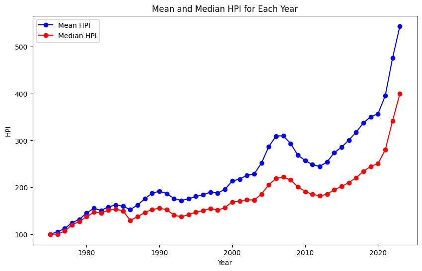

```python
"""
This block of code adjusts the types of HPI and Year values, drops all of the NaN values in HPI, and calculates the mean and median for each year

The mean and median are the measures of central tendancy used in the line graph also created in this block
"""
hpi_df['HPI'] = pd.to_numeric(hpi_df['HPI'], errors='coerce')
hpi_df['Year'] = pd.to_numeric(hpi_df['Year'], errors='coerce')


hpi_df = hpi_df.dropna(subset=['HPI']) # clean up values --> drop all NaN
mean_per_year = hpi_df.groupby('Year')['HPI'].mean() # calculate mean
ax = mean_per_year.plot(kind='line', marker='o', color='blue', figsize=(10, 6), label='Mean HPI')

median_per_year = hpi_df.groupby('Year')['HPI'].median() # calculate median
median_per_year.plot(kind='line', marker='o', color='red', ax=ax, label='Median HPI')

# Title and labels
ax.set_title('Mean and Median HPI for Each Year')
ax.set_xlabel('Year')
ax.set_ylabel('HPI')

ax.legend()
```

The visualization above displays the mean and median housing price index per year, for each year from 1975 - 2023. It is helpful to see how housing prices fluctuate over time. Dips in the trendline could be due to a variety of economic factors, some having to do with the environment! Since the mean is consistently higher than the median, it could indicate that the housing market is skewed towards higher-priced homes. Natural disasters often impact different segments of the housing market in different ways. For example, high-value or luxury homes might see a more significant price drop or a longer recovery time, while more affordable homes may experience a quicker rebound or less volatility.

```python
# Some interesting Stats

# lowest and highest hpi years
highest_hpi = hpi_df.groupby('Year')['HPI'].mean().idxmax()
print(f"The year with the highest average HPI is {highest_hpi}.")

lowest_hpi = hpi_df.groupby('Year')['HPI'].mean().idxmin()
print(f"The year with the lowest average HPI is {lowest_hpi}.")

# year with most reported data
top_years = hpi_df['Year'].value_counts().head(5)
print(top_years)

print("The most frequent year reported in the data is")

#calculate standard deviation
std= hpi_df['HPI'].std()
print(f"The standard deviation of the HPI is {std}")

smallest = hpi_df.groupby('Five-Digit ZIP Code')['HPI'].mean().nsmallest(5)
smallest
```

```
The year with the highest average HPI is 2023.
The year with the lowest average HPI is 1975.
Year
2021    18818
2012    18795
2013    18782
2020    18771
2009    18730
Name: count, dtype: int64
The most frequent year reported in the data is
The standard deviation of the HPI is 235.45070972223266
```

| Five-Digit ZIP Code | HPI |
| --- | --- |
| 92230 | 72.109333 |
| 34449 | 76.544000 |
| 92249 | 78.201667 |
| 93219 | 79.705000 |
| 93256 | 80.571429 |

**dtype:** float64

## Some Summary Statistics

The years with the highest HPI is 2023, and the lowest is 1975. This should not be suprising based on market and housing trands, and this conclusion can also be drawn from looking at the graph

The most frequent year reported in the data is 2021. This is followed by 2012, 2013, 2020, 2009

- The dataset includes more recent data
- If a particular year is overrepresented, it might correspond to a major real estate event

The standard deviation is about 235.45

- 235.45 is relatively large, suggesting that the data points are spread out far from the mean value. Suggests a wide variability in the dataset.
- A standard deviation of 235.45 could mean that housing prices vary quite a bit, depending on the range of prices (ex: a small neighborhood vs. a wide range of house prices).

The five zip codes with the smallest hpi are 92230, 34449, 92249, 93219, and 93256

1. 92230 – Blythe, California Blythe is a city located in Riverside County, California, near the Arizona border.
2. 34449 – Homosassa, Florida Homosassa is a census-designated place in Citrus County, Florida, located on the Gulf Coast.
3. 92249 – Calexico, California Calexico is a city in Imperial County, California, located near the U.S.-Mexico border.
4. 93219 – Coalinga, California Coalinga is a city in Fresno County, California, located in the San Joaquin Valley.
5. 93256 – Huron, California Huron is a city in Fresno County, California, also located in the San Joaquin Valley.
- HPI in these areas could be due to variety of factors, like most of them are semi-rural. In terms of environmental factors, some of these areas, like Blythe and Coalinga, are located in desert regions or areas prone to extreme weather, which can make them less appealing for long-term living.

## Table 2:

The next dataset we are working with is FEMA’s Disaster Declarations Summaries.

This dataset comes from FEMA's website: https://www.fema.gov/openfema-data-page/disaster-declarations-summaries-v2

This dataset lists all federally declared disasters with relevant attributes such as date, type, and duration. We chose this dataset because it provides detailed records of natural disasters. This will allow us to identify when and where disasters occurred and then analyze their impact on housing markets in affected regions. A question we have for this dataset is what types of natural disasters have the most significant and longest impact on housing prices in affected areas?

```python
# Orginal dtypes of the different columns
print(disasterDeclaration_df.dtypes)
```

```
femaDeclarationString       object
disasterNumber               int64
state                       object
declarationType             object
declarationDate             object
fyDeclared                   int64
incidentType                object
declarationTitle            object
ihProgramDeclared            int64
iaProgramDeclared            int64
paProgramDeclared            int64
hmProgramDeclared            int64
incidentBeginDate           object
incidentEndDate             object
disasterCloseoutDate        object
tribalRequest                int64
fipsStateCode                int64
fipsCountyCode               int64
placeCode                    int64
designatedArea              object
declarationRequestNumber     int64
lastIAFilingDate            object
incidentId                   int64
region                       int64
designatedIncidentTypes     object
lastRefresh                 object
hash                        object
id                          object
dtype: object
```

This dataset has a lot of unnecessary columns that we need to get rid of. With cleaning the data we will be left with only the necessary columns needed for analysis. The columns we want are: State, declarationType, Declaration Date, Fiscal Year Declared, Incident Type, Declaration Title,Incident Begin Date, Incident End Date, disasterCloseoutDate, and Designated Area.

```python
disasterDeclaration_df.head()
```

|  | femaDeclarationString | disasterNumber | state | declarationType | declarationDate | fyDeclared | incidentType | declarationTitle | ihProgramDeclared | iaProgramDeclared | paProgramDeclared | hmProgramDeclared | incidentBeginDate | incidentEndDate | disasterCloseoutDate | tribalRequest | fipsStateCode | fipsCountyCode | placeCode | designatedArea | declarationRequestNumber | lastIAFilingDate | incidentId | region | designatedIncidentTypes | lastRefresh | hash | id |
| --- | --- | --- | --- | --- | --- | --- | --- | --- | --- | --- | --- | --- | --- | --- | --- | --- | --- | --- | --- | --- | --- | --- | --- | --- | --- | --- | --- | --- |
| 0 | FM-5529-OR | 5529 | OR | FM | 2024-08-09T00:00:00.000Z | 2024 | Fire | LEE FALLS FIRE | 0 | 0 | 1 | 1 | 2024-08-08T00:00:00.000Z | NaN | NaN | 0 | 41 | 67 | 99067 | Washington (County) | 24122 | NaN | 2024081001 | 10 | R | 2024-08-27T18:22:14.800Z | ae87cf3c6ed795015b714af7166c7c295b2b67c7 | 09e3f81a-5e16-4b72-b317-1c64e0cfa59c |
| 1 | FM-5528-OR | 5528 | OR | FM | 2024-08-06T00:00:00.000Z | 2024 | Fire | ELK LANE FIRE | 0 | 0 | 1 | 1 | 2024-08-04T00:00:00.000Z | NaN | NaN | 0 | 41 | 31 | 99031 | Jefferson (County) | 24116 | NaN | 2024080701 | 10 | R | 2024-08-27T18:22:14.800Z | 432cf0995c47e3895cea696ede5621b810460501 | 59983f89-30bf-4888-b21b-62e8d57d9aac |
| 2 | FM-5527-OR | 5527 | OR | FM | 2024-08-02T00:00:00.000Z | 2024 | Fire | MILE MARKER 132 FIRE | 0 | 0 | 1 | 1 | 2024-08-02T00:00:00.000Z | NaN | NaN | 0 | 41 | 17 | 99017 | Deschutes (County) | 24111 | NaN | 2024080301 | 10 | R | 2024-08-27T18:22:14.800Z | 2f21d90cb6bc64b0d4121aa3f18d852bbb4b11fa | 8d13ecf0-bc2f-496b-8c9f-b2e73da832a0 |
| 3 | FM-5521-WA | 5521 | WA | FM | 2024-07-26T00:00:00.000Z | 2024 | Fire | RETREAT FIRE | 0 | 0 | 1 | 1 | 2024-07-23T00:00:00.000Z | NaN | NaN | 0 | 53 | 77 | 99077 | Yakima (County) | 24098 | NaN | 2024072601 | 10 | R | 2024-08-27T18:22:14.800Z | e205f5a4b56cadd811661c07fc8a8143b6c8c604 | bc02a243-2458-4af3-84e3-b9928bd1d41d |
| 4 | FM-5520-ID | 5520 | ID | FM | 2024-07-26T00:00:00.000Z | 2024 | Fire | GWEN FIRE | 0 | 0 | 1 | 1 | 2024-07-25T00:00:00.000Z | NaN | NaN | 0 | 16 | 0 | 57340 | Nez Perce Indian Reservation | 24099 | NaN | 2024072602 | 10 | R | 2024-08-27T18:22:14.800Z | ba084caa4ee18c9c0c4383346e7669d4af4ab9b7 | 85cccdec-5e22-436f-a3e7-acd7340172cf |

```python
#Drops the not needed columns since we do not need that data from the dataset
disasterDeclaration_df.drop(columns=[
    "femaDeclarationString", "disasterNumber", "ihProgramDeclared", "iaProgramDeclared",
    "paProgramDeclared", "hmProgramDeclared", "placeCode", "declarationRequestNumber",
    "lastIAFilingDate", "designatedIncidentTypes", "lastRefresh", "hash", "id",
    "tribalRequest", "fipsStateCode", "fipsCountyCode", "incidentId", "region"
], inplace=True, errors="ignore")

#Resets the index after dropping the unrevlant columns
disasterDeclaration_df = disasterDeclaration_df.reset_index(drop=True)

#Changes the columns names so they follow the same format
disasterDeclaration_df = disasterDeclaration_df.rename(columns={
    "state": "State",
    "declarationDate": "Declaration Date",
    "fyDeclared": "Fiscal Year Declared",
    "incidentType": "Incident Type",
    "declarationTitle": "Declaration Title",
    "incidentBeginDate": "Incident Begin Date",
    "incidentEndDate": "Incident End Date",
    "designatedArea": "Designated Area"
})

#Cleans the designated Area column
def clean(entry):
    if pd.isna(entry):
        return entry
    return entry.lower().replace(" (county)", "").strip()

disasterDeclaration_df['Designated Area'] = disasterDeclaration_df['Designated Area'].apply(clean)

#Replaces empty or invalid values with NaN so we can get rid of NaN values later on
def replaceNan(entry):
    entry = str(entry).strip()
    if entry in ["–", '="0"', '="0.00"', "", "nan"]:
        return np.nan
    return entry

#Apply NaN replacement to all columns
for col in disasterDeclaration_df.columns:
    disasterDeclaration_df[col] = disasterDeclaration_df[col].apply(replaceNan)

#Drops all rows containing NaN values since we are not looking at rows with nan values
disasterDeclaration_df.dropna(inplace=True)

#Resets the index after dropping NaN rows
disasterDeclaration_df = disasterDeclaration_df.reset_index(drop=True)
```

We want to collect data only U.S. states and filter out the data on U.S. territories.

```python
# List of valid U.S. state abbreviations (50 states + DC)
valid_states = [
    'AL', 'AK', 'AZ', 'AR', 'CA', 'CO', 'CT', 'DE', 'FL', 'GA',
    'HI', 'ID', 'IL', 'IN', 'IA', 'KS', 'KY', 'LA', 'ME', 'MD',
    'MA', 'MI', 'MN', 'MS', 'MO', 'MT', 'NE', 'NV', 'NH', 'NJ',
    'NM', 'NY', 'NC', 'ND', 'OH', 'OK', 'OR', 'PA', 'RI', 'SC',
    'SD', 'TN', 'TX', 'UT', 'VT', 'VA', 'WA', 'WV', 'WI', 'WY', 'DC'
]

# Filter disaster_df to only include those states
disasterDeclaration_df = disasterDeclaration_df[disasterDeclaration_df['State'].isin(valid_states)].reset_index(drop=True)
```

```python
# dtypes of the different columns after cleaning
print(disasterDeclaration_df.dtypes)
```

```
State                   object
declarationType         object
Declaration Date        object
Fiscal Year Declared    object
Incident Type           object
Declaration Title       object
Incident Begin Date     object
Incident End Date       object
disasterCloseoutDate    object
Designated Area         object
dtype: object
```

```python
#Displays the cleaned data
disasterDeclaration_df.head()
```

|  | State | declarationType | Declaration Date | Fiscal Year Declared | Incident Type | Declaration Title | Incident Begin Date | Incident End Date | disasterCloseoutDate | Designated Area |
| --- | --- | --- | --- | --- | --- | --- | --- | --- | --- | --- |
| 0 | NM | FM | 2022-04-30T00:00:00.000Z | 2022 | Fire | CALF CANYON FIRE | 2022-04-20T00:00:00.000Z | 2022-07-23T00:00:00.000Z | 2024-06-25T00:00:00.000Z | san miguel |
| 1 | NM | FM | 2022-04-28T00:00:00.000Z | 2022 | Fire | COOK'S PEAK FIRE | 2022-04-28T00:00:00.000Z | 2022-07-23T00:00:00.000Z | 2024-06-25T00:00:00.000Z | colfax |
| 2 | NM | FM | 2022-04-12T00:00:00.000Z | 2022 | Fire | NOGAL CANYON FIRE | 2022-04-12T00:00:00.000Z | 2022-07-23T00:00:00.000Z | 2024-06-25T00:00:00.000Z | lincoln |
| 3 | NM | FM | 2022-04-12T00:00:00.000Z | 2022 | Fire | MCBRIDE FIRE | 2022-04-12T00:00:00.000Z | 2022-07-23T00:00:00.000Z | 2024-06-25T00:00:00.000Z | lincoln |
| 4 | NM | FM | 2022-04-12T00:00:00.000Z | 2022 | Fire | HERMIT'S PEAK FIRE | 2022-04-12T00:00:00.000Z | 2022-07-23T00:00:00.000Z | 2024-06-20T00:00:00.000Z | san miguel |

This dataset can be used to answer the research question by obtaining different types of natural disaster events with their relevant information. We can use this dataset to see when and where a natural disaster occurs. Then we can use the House Price Index dataset to see how housing pricing changes in those areas before, after, and during the natural disaster.

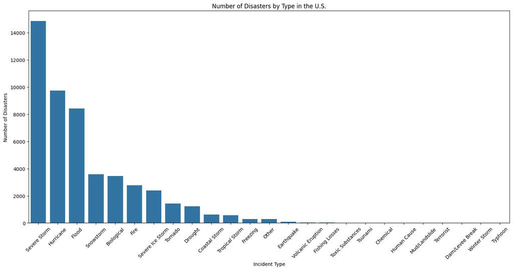

```python
import matplotlib.pyplot as plt
import seaborn as sns

#Gets the number of disasters by the incident type
disasterCounts = disasterDeclaration_df["Incident Type"].value_counts()

#Bar graph of each of the number of disater by types
plt.figure(figsize=(18, 8))
sns.barplot(x=disasterCounts.index, y=disasterCounts.values)
plt.xticks(rotation=45)
plt.xlabel("Incident Type")
plt.ylabel("Number of Disasters")
plt.title("Number of Disasters by Type in the U.S.")
plt.show()
```

Summary Statistics:

These statistics review frequency levels of natural disasters to see which occur the most.

The data shows that weather related events (storms, hurricanes, floods) are the highest occuring and recorded natural disasters in the FEMA’s Disaster Declarations Summaries, while geological disasters (earthquakes, volcanic eruptions, tsunamis) do not occur as often.

This is relevant to the research question because it shows which types of natural disasters occur the most frequently and have the greatest potential impact on the housing market.

Now we are going to find the years where the highest and lowest number of natural disasters occurred.

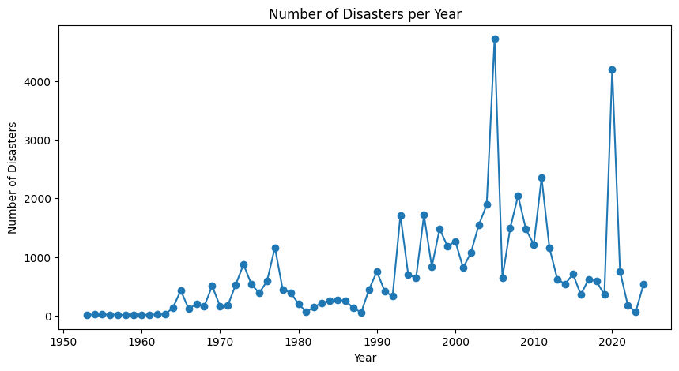

```python
# Changes the Incident Begin Date column to datetime and gets the year
disasterDeclaration_df['Incident Year'] = pd.to_datetime(disasterDeclaration_df['Incident Begin Date']).dt.year

# Counts the number of disasters for each year and sorts by year
disasters_perYear = disasterDeclaration_df['Incident Year'].value_counts().sort_index()

# Displays a line plot showing the number of disasters per year
plt.figure(figsize=(10, 5))
plt.plot(disasters_perYear.index, disasters_perYear.values, marker='o')
plt.title("Number of Disasters per Year")
plt.xlabel("Year")
plt.ylabel("Number of Disasters")
plt.show()
```

```python
# Count the number of disasters per year
disasters_per_year = disasterDeclaration_df['Incident Year'].value_counts().sort_values(ascending=False)

# Make DataFrame
top_disaster_years = disasters_per_year.reset_index()
top_disaster_years.columns = ['Year', 'Number of Disasters']

# Display the top 5 years with the most disasters
top_disaster_years.head(5)
```

|  | Year | Number of Disasters |
| --- | --- | --- |
| 0 | 2005 | 4723 |
| 1 | 2020 | 4203 |
| 2 | 2011 | 2354 |
| 3 | 2008 | 2044 |
| 4 | 2004 | 1891 |

```python
# Count the number of disasters per year
disasters_per_year = disasterDeclaration_df['Incident Year'].value_counts().sort_values(ascending=True)

# Make DataFrame
low_disaster_years = disasters_per_year.reset_index()
low_disaster_years.columns = ['Year', 'Number of Disasters']

# Display the lowest 5 years with the least disasters
low_disaster_years.head(5)
```

|  | Year | Number of Disasters |
| --- | --- | --- |
| 0 | 1958 | 7 |
| 1 | 1959 | 7 |
| 2 | 1960 | 12 |
| 3 | 1961 | 12 |
| 4 | 1953 | 13 |

This plot shows how the number of disasters per year changes over time.

Summary Statistics:

Now we are going to find the states with the most amount of disaster declarations and least amount of disaster declarations.

```python
# Get the top 5 states with the most disaster declarations
top_disaster_states = disasterDeclaration_df['State'].value_counts().head(5)

# Make DataFrame
top_disaster_states_df = top_disaster_states.reset_index()
top_disaster_states_df.columns = ['State', 'Number of Disasters']

# Display
top_disaster_states_df
```

|  | State | Number of Disasters |
| --- | --- | --- |
| 0 | TX | 4163 |
| 1 | MO | 2345 |
| 2 | VA | 2211 |
| 3 | OK | 2046 |
| 4 | KY | 2014 |

```python
# Get the 5 states with the fewest disaster declarations
low_disaster_states = disasterDeclaration_df['State'].value_counts().sort_values().head(5)

# Make DataFrame
low_disaster_states_df = low_disaster_states.reset_index()
low_disaster_states_df.columns = ['State', 'Number of Disasters']

# Display
low_disaster_states_df
```

|  | State | Number of Disasters |
| --- | --- | --- |
| 0 | DC | 21 |
| 1 | DE | 47 |
| 2 | HI | 75 |
| 3 | WY | 95 |
| 4 | RI | 100 |

Summary Statistics:

1. Top 5 Disaster Heavy States: Texas, Missouri, Virginia, Oklahoma, and Kentucky.
2. Bottom 5 Disaster Light States: District of Columbia, Delaware, Hawaii, Wyoming, Rhode Island.
3. The highest number of disasters in any state is Texas with 4163 recorded disasters.
4. The lowest number of disasters in any state is District of Columbia with 21 recorded disasters.
- District of Columbia is a Federal District and not a state, but is included in many datasets.

We will use these results to compare housing price trends between disaster heavy and disaster light regions.

## Table 3:

The next dataset we are working with is the US ZIP Codes Database by SimpleMaps.

This dataset comes from SimpleMaps: https://simplemaps.com/data/us-zips

This dataset provides detailed information about every ZIP code in the United States, including the state, population, and geographic coordinates. We chose this dataset to map ZIP codes from the HPI dataset to their respective states. The HPI dataset had only ZIP codes for location and the Disaster Declarations Summaries dataset only had states for locations. We needed this US ZIP Code Dataset to match the two datasets. This will allow for state-level analysis of housing trends. A question we have for this dataset is whether the location of a ZIP code affects how housing prices respond to natural disasters.

```python
# Orginal dtypes of the different columns
print(zip_state_df.dtypes)
```

```
zip                   int64
lat                 float64
lng                 float64
city                 object
state_id             object
state_name           object
zcta                   bool
parent_zcta         float64
population          float64
density             float64
county_fips           int64
county_name          object
county_weights       object
county_names_all     object
county_fips_all      object
imprecise              bool
military               bool
timezone             object
dtype: object
```

This dataset has a lot of unnecessary columns that we need to get rid of. With cleaning the data we will be left with only the necessary columns needed for analysis. We only want the zip column and state_id column so we can match the 2 previous datasets.

```python
# Keeps only ZIP code and state ID
zip_state_df = zip_state_df[['zip', 'state_id']]

# Makes sure ZIP codes are strings and padded with leading zeros to 5 digits for consistency with HPI dataset
zip_state_df['zip'] = zip_state_df['zip'].astype(str).str.zfill(5)
```

```python
# dtypes of the different columns after cleaning
print(zip_state_df.dtypes)
```

```
zip         object
state_id    object
dtype: object
```

```python
zip_state_df.head()
```

|  | zip | state_id |
| --- | --- | --- |
| 0 | 00601 | PR |
| 1 | 00602 | PR |
| 2 | 00603 | PR |
| 3 | 00606 | PR |
| 4 | 00610 | PR |

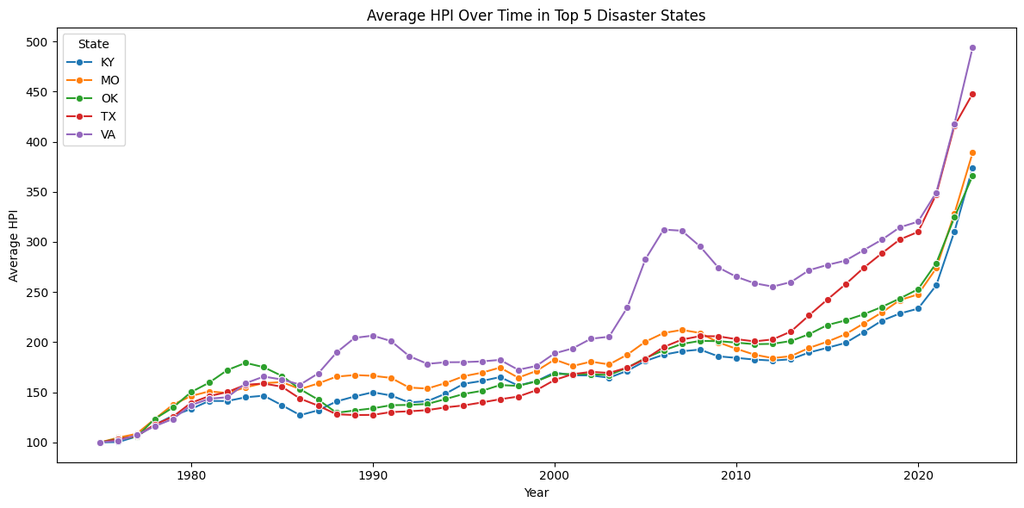

```python
import matplotlib.pyplot as plt
import seaborn as sns

# Make Year and HPI are numeric
hpi_df['Year'] = pd.to_numeric(hpi_df['Year'])
hpi_df['HPI'] = pd.to_numeric(hpi_df['HPI'])
# Make sure data is cleaned
hpi_df = hpi_df.dropna(subset=['Year', 'HPI'])

# ZIPs are padded with 0 in front so both ZIP codes from HPI dataset and ZIP Code dataset are in the same format
hpi_df['Five-Digit ZIP Code'] = hpi_df['Five-Digit ZIP Code'].astype(str).str.zfill(5)
zip_state_df['zip'] = zip_state_df['zip'].astype(str).str.zfill(5)

# Merge with ZIP-to-state info
merged_hpi = hpi_df.merge(zip_state_df, left_on='Five-Digit ZIP Code', right_on='zip')

# Get the top 5 disaster heavy states from disasterDeclaration_df
top_states = disasterDeclaration_df['State'].value_counts().head(5).index

# Filter data to only get the top 5 states
merged_top = merged_hpi[merged_hpi['state_id'].isin(top_states)]

# Group by state and year then calculate average HPI
avg_hpi_byYear = merged_top.groupby(['state_id', 'Year'])['HPI'].mean().reset_index()

# Plot line graph
plt.figure(figsize=(12, 6))
sns.lineplot(data=avg_hpi_byYear, x='Year', y='HPI', hue='state_id', marker='o')
plt.title("Average HPI Over Time in Top 5 Disaster States")
plt.xlabel("Year")
plt.ylabel("Average HPI")
plt.legend(title="State")
plt.tight_layout()
plt.show()
```

```python
# Summary statistics for average HPI by state over time
avg_hpi_byYear.groupby('state_id')['HPI'].describe()
```

| state_id | count | mean | std | min | 25% | 50% | 75% | max |
| --- | --- | --- | --- | --- | --- | --- | --- | --- |
| KY | 49.0 | 171.352860 | 49.308947 | 100.0 | 141.276061 | 164.525374 | 187.467900 | 373.958827 |
| MO | 49.0 | 183.694016 | 50.502855 | 100.0 | 158.808993 | 174.614153 | 200.414392 | 388.934324 |
| OK | 49.0 | 179.288707 | 52.228874 | 100.0 | 143.219391 | 168.109817 | 200.992437 | 365.915588 |
| TX | 49.0 | 186.449992 | 76.427185 | 100.0 | 136.595208 | 158.738902 | 205.828273 | 447.791304 |
| VA | 49.0 | 222.168087 | 81.688672 | 100.0 | 168.836850 | 201.080682 | 276.958773 | 493.827178 |

Summary Statistics:

This graph shows the trend of average Housing Price Index from 1975 to 2023 across the five U.S. states with the most natural disaster declarations.

1. All states start around an HPI of 100.
2. Virginia had the highest mean and max HPI. Virginia also had the greatest variation (std).
3. Texas also had huge growth and variation.
4. Kentucky had the lowest mean HPI, which suggested slower long term housing growth despite having high disaster frequency.

Analyzing HPI trends in disaster heavy states helps us understand whether natural disasters have long term economic impacts on housing.

In the next step, this can be compared against low disaster states to explore whether frequency of disasters has any worsening effect on housing market performance.

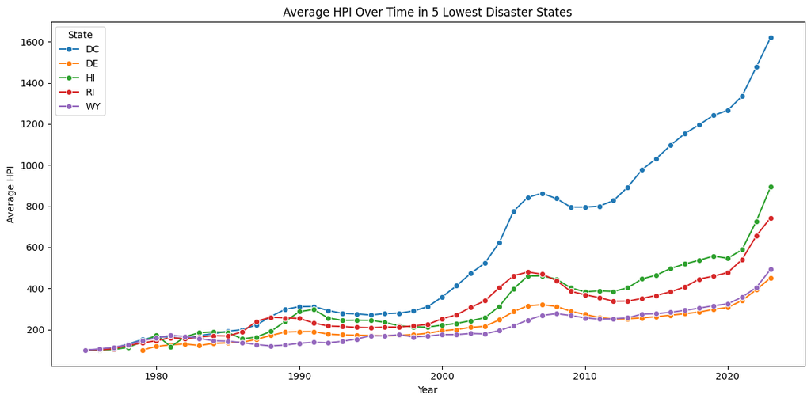

```python
import matplotlib.pyplot as plt
import seaborn as sns

# Make Year and HPI numeric
hpi_df['Year'] = pd.to_numeric(hpi_df['Year'])
hpi_df['HPI'] = pd.to_numeric(hpi_df['HPI'])
# Make sure data is cleaned
hpi_df = hpi_df.dropna(subset=['Year', 'HPI'])

# ZIPs are padded with 0 in front so both ZIP codes from HPI dataset and ZIP Code dataset are in the same format
hpi_df['Five-Digit ZIP Code'] = hpi_df['Five-Digit ZIP Code'].astype(str).str.zfill(5)
zip_state_df['zip'] = zip_state_df['zip'].astype(str).str.zfill(5)

# Merge with ZIP-to-state info
merged_hpi = hpi_df.merge(zip_state_df, left_on='Five-Digit ZIP Code', right_on='zip')

# Get the 5 states with the fewest disaster declarations
low_states = disasterDeclaration_df['State'].value_counts().sort_values().head(5).index

# Filter merged HPI data for those 5 lowest disaster states
merged_low = merged_hpi[merged_hpi['state_id'].isin(low_states)]

# Group by state and year then calculate average HPI
avg_hpi_byYear = merged_low.groupby(['state_id', 'Year'])['HPI'].mean().reset_index()

# Plot the line graph
plt.figure(figsize=(12, 6))
sns.lineplot(data=avg_hpi_byYear, x='Year', y='HPI', hue='state_id', marker='o')
plt.title("Average HPI Over Time in 5 Lowest Disaster States")
plt.xlabel("Year")
plt.ylabel("Average HPI")
plt.legend(title="State")
plt.tight_layout()
plt.show()
```

```python
# Summary statistics for average HPI by state over time
avg_hpi_byYear.groupby('state_id')['HPI'].describe()
```

| state_id | count | mean | std | min | 25% | 50% | 75% | max |
| --- | --- | --- | --- | --- | --- | --- | --- | --- |
| DC | 49.0 | 565.380978 | 425.925118 | 100.000000 | 222.326000 | 311.873333 | 843.136667 | 1619.633333 |
| DE | 45.0 | 223.175420 | 78.258917 | 100.000000 | 170.970370 | 199.907778 | 276.479615 | 451.536190 |
| HI | 49.0 | 316.818355 | 173.360663 | 99.724286 | 187.973333 | 245.188913 | 445.367059 | 893.207000 |
| RI | 49.0 | 300.074191 | 144.466727 | 100.000000 | 208.656167 | 256.437451 | 385.781176 | 743.671000 |
| WY | 49.0 | 206.223334 | 84.104488 | 100.000000 | 143.170000 | 174.397419 | 268.064444 | 492.563429 |

Summary Statistics:

This graph shows the trend of average Housing Price Index from 1975 to 2023 across the five U.S. states with the least amount natural disaster declarations.

1. DC stands out with an exceptionally high HPI average and the largest growth over time. This can be caused by demand, urbanization, and limited housing supply.
2. All states experienced growth after 2000 and another large surge after 2020. This is very similar to national housing trends.
3. Hawaii and Rhode Island show strong HPI values despite having fewer disasters, this suggest other factors are driving prices.

The average HPI values in low disaster states are significantly higher than in high disaster states. This suggests that limited exposure to natural disasters may contribute to stronger or more stable housing markets over time.

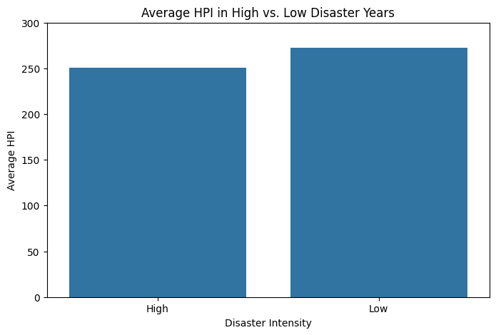

```python
# Define high disaster years
high_disaster_years = disasters_perYear[disasters_perYear > disasters_perYear.mean()].index

def classify(year):
    if year in high_disaster_years:
        return 'High'
    else:
        return 'Low'

hpi_df['Disaster Intensity'] = hpi_df['Year'].apply(classify)

# Group by Disaster Intensity and then calculate mean HPI
mean_hpi_by_disaster = hpi_df.groupby('Disaster Intensity')['HPI'].mean().reset_index()

# Plot using a bar graph
plt.figure(figsize=(8, 5))
sns.barplot(data=mean_hpi_by_disaster, x='Disaster Intensity', y='HPI')
plt.title('Average HPI in High vs. Low Disaster Years')
plt.xlabel('Disaster Intensity')
plt.ylabel('Average HPI')
plt.ylim(0, 300)
plt.show()
```

Summary Statistics:

The bar graph compares the mean Housing Price Index across two groups of years:

1. High disaster years: years with a number of federally declared disasters above the average.
2. Low disaster years: years with fewer disasters than the average.

The graph helps you explore whether the frequency of disasters in a given year has a effect on average home prices.

Disaster Intensity for High has an average HPI of around 252.

Low disaster years had a slightly higher average HPI than high disaster years.

```python
'''HERE I have to find a dataset that connects the Zip Codes with states, then sort hpi index
by 5 hightest states. The 5 most disaster prone states will probably show a larger difference.
you can add a state column to your hpi_df DataFrame by merging it with the zip_state_df
DataFrame, which contains the mapping between ZIP codes and states'''

# Ensure ZIP codes are strings and padded with leading zeros
hpi_df['Five-Digit ZIP Code'] = hpi_df['Five-Digit ZIP Code'].astype(str).str.zfill(5)
zip_state_df['zip'] = zip_state_df['zip'].astype(str).str.zfill(5)

# Merge with ZIP-to-state info
hpi_df = pd.merge(hpi_df, zip_state_df, left_on='Five-Digit ZIP Code', right_on='zip', how='left')
```

```python
hpi_df.head()
top_states_list = top_states.tolist()  # Convert Index to list
hpi_top = hpi_df[hpi_df['state_id'].isin(top_states_list)]  # Filter by states
```

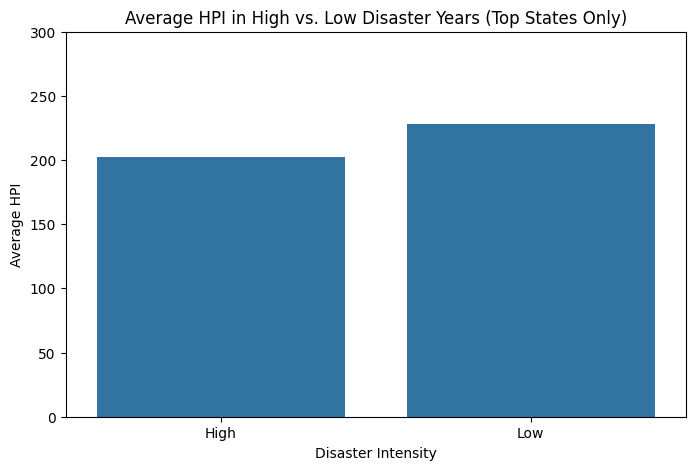

```python
high_disaster_years = disasters_perYear[disasters_perYear > disasters_perYear.mean()].index

def classify(year):
    return 'High' if year in high_disaster_years else 'Low'

# Apply classification based on filtered dataset
hpi_top['Disaster Intensity'] = hpi_top['Year'].apply(classify)

# Group by Disaster Intensity and then calculate mean HPI
mean_hpi_by_disaster = hpi_top.groupby('Disaster Intensity')['HPI'].mean().reset_index()

# Plot using a bar graph
plt.figure(figsize=(8, 5))
sns.barplot(data=mean_hpi_by_disaster, x='Disaster Intensity', y='HPI')
plt.title('Average HPI in High vs. Low Disaster Years (Top States Only)')
plt.xlabel('Disaster Intensity')
plt.ylabel('Average HPI')
plt.ylim(0, 300)
plt.show()
```

Summary Statistics:

The bar graph compares the mean Housing Price Index across two groups of years: Top states of Average HPI in High vs. Low Disaster Years

Disaster Intensity for High top stateshas an average HPI of around 200.

Low disaster years had a slightly higher average HPI than high disaster years.

The difference is not extreme but is consistent with the idea that years with fewer disasters will be more favorable for housing market performance on average.

# Science and Model

We chose two models for this project: Linear Regression and K-Nearest Neighbors Regression (KNN)

- Linear Regression was chosen because it is easy to understand and good at showing long term trends. HPI usually goes up over time, a linear model helps us see that general increase and compare how much prices rise in states with lots of disasters versus those with fewer
- K-Nearest Neighbors (KNN) Regression was picked because it does not assume a straight line pattern. KNN looks at patterns in the data and predicts based on years that are similar to the one we are trying to predict.

Both models use Year to predict HPI and assume it is an important factor. We ran separate models for the top 5 and bottom 5 disaster prone states to better understand how disasters might affect housing prices differently across regions.

The independent variable is Year, and the dependent variable is the Housing Price Index (HPI). We aim to predict based on time and disaster frequency.

# Model 1: Linear Regression

The first model we chose to include was a linear regression model to predict the HPI for a given year. Included are two linear regression models on the top five disaster frequent states and the botton 5 disaster frequent states. Since HPI has generally been increasing over time, using a linear model can capture this upward trend. What we really want to find is how HPI predictions change based on whether the state frequently has disasters or not.

```python
'''linear regression model for HPI and year for just the top 5 disaster states'''
from sklearn.model_selection import train_test_split
from sklearn.linear_model import LinearRegression
from sklearn.metrics import mean_squared_error, r2_score


# Prepare the data
X = hpi_top[['Year']]  # Features (Year)
y = hpi_top['HPI']      # Target variable (HPI)

# Split data into training and testing sets
X_train, X_test, y_train, y_test = train_test_split(X, y, test_size=0.2, random_state=42)

# Create and train the linear regression model
model = LinearRegression()
model.fit(X_train, y_train)

# Make predictions on the test set
y_pred = model.predict(X_test)

# Evaluate the model
mse = mean_squared_error(y_test, y_pred)
r2 = r2_score(y_test, y_pred)

print(f"Mean Squared Error: {mse}")
print(f"R-squared: {r2}")

# Example prediction
new_year = [[2024]]  # Example: predict HPI for the year 2024
predicted_hpi = model.predict(new_year)
print(f"Predicted HPI in top disaster states for 2024: {predicted_hpi[0]}")
```

```
Mean Squared Error: 19467.473766753494
R-squared: 0.13171499380784402
Predicted HPI in top disaster states for 2024: 302.4159885884983
```

```python
low_states_list = low_states.tolist()  # Convert Index to list
hpi_low = hpi_df[hpi_df['state_id'].isin(low_states_list)]  # Filter by states
```

```python
'''linear regression model for HPI and year for just the bottom 5 disaster states'''
# Prepare the data
X2 = hpi_low[['Year']]  # Features (Year)
y2 = hpi_low['HPI']      # Target variable (HPI)

# Split data into training and testing sets
X_train2, X_test2, y_train2, y_test2 = train_test_split(X2, y2, test_size=0.2, random_state=7)

# Create and train the linear regression model
model_2 = LinearRegression()
model_2.fit(X_train2, y_train2)

# Make predictions on the test set
y_pred2 = model_2.predict(X_test2)

# Evaluate the model
mse_2 = mean_squared_error(y_test2, y_pred2)
r2_2 = r2_score(y_test2, y_pred2)

print(f"Mean Squared Error: {mse_2}")
print(f"R-squared: {r2_2}")

# Example prediction
new_year = [[2024]]  # Example: predict HPI for the year 2024
predicted_hpi_2 = model_2.predict(new_year)
print(f"Predicted HPI in low disaster states for 2024: {predicted_hpi_2[0]}")
```

```
Mean Squared Error: 63306.68720482391
R-squared: 0.18934776399768072
Predicted HPI in low disaster states for 2024: 521.8025561454924
```

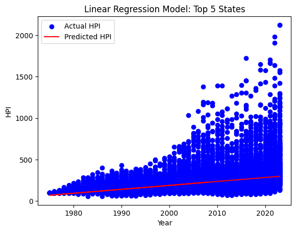

```python
# Assuming 'X_test' and 'y_pred' are already defined from the previous code
import matplotlib.pyplot as plt
plt.scatter(X_test, y_test, color='blue', label='Actual HPI')
plt.plot(X_test, y_pred, color='red', label='Predicted HPI')
plt.xlabel('Year')
plt.ylabel('HPI')
plt.title('Linear Regression Model: Top 5 States')
plt.legend()
plt.show()
```

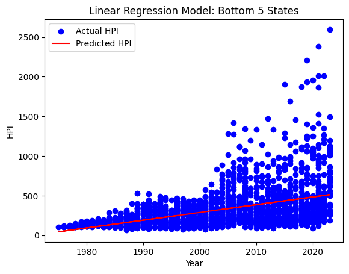

```python
plt.scatter(X_test2, y_test2, color='blue', label='Actual HPI')
plt.plot(X_test2, y_pred2, color='red', label='Predicted HPI')
plt.xlabel('Year')
plt.ylabel('HPI')
plt.title('Linear Regression Model: Bottom 5 States')
plt.legend()
plt.show()
```

## Predictions: Linear Regression

**HPI** stands for **Housing Price Index**. It's a normalized index used to track changes in home prices over time. Considering the predicted HPI for 2024, the average HPI in the **top five disaster states** was predicted to be **~302** and the **bottom five disaster states** was predicted to be **~522**.

An HPI value of:

- 100: typically represents prices at a baseline year (often 2000 or 1980 depending on the dataset).
- 300: means housing prices have tripled compared to that baseline.
- 500: means prices have increased fivefold from the baseline.

So, if a state has an HPI of 300, its housing market has seen moderate growth. If another has an HPI of 500, it has experienced much stronger price appreciation.

# Model 2: K-Nearest Neighbors Regression

The second model we chose was a K-Nearest Neighbors (KNN) Regression model to predict the Housing Price Index (HPI) based on the year. Linear regression fits a straight line while KNN uses the average HPI of the k closest data points in time to make its prediction. This can capture more localized trends and a non linear patterns in the housing market data.

```python
'''K-Nearest Neighbors Regression for HPI and year for just the top 5 disaster states'''
from sklearn.neighbors import KNeighborsRegressor
from sklearn.model_selection import train_test_split
from sklearn.metrics import mean_squared_error, r2_score
import matplotlib.pyplot as plt

# Prepare the data
XTopKnn = hpi_top[['Year']]
yTopKnn = hpi_top['HPI']

# Train test split
XTrainKnn, XTestKnn, yTrainKnn, yTestKnn = train_test_split(XTopKnn, yTopKnn, test_size=0.2, random_state=42)

# Train KNN model
knnModel = KNeighborsRegressor(n_neighbors=5)
knnModel.fit(XTrainKnn, yTrainKnn)

# Make predictions on the test set
yPredKnn = knnModel.predict(XTestKnn)

# Evaluate the model
mseknn = mean_squared_error(yTestKnn, yPredKnn)
r2knn = r2_score(yTestKnn, yPredKnn)

print(f"KNN Mean Squared Error (Top States): {mseknn}")
print(f"KNN R-squared (Top States): {r2knn}")

# Example prediction
new_year = [[2024]]  # Example: predict HPI for the year 2024
predicted_hpi = knnModel.predict(new_year)
print(f"Predicted HPI in top disaster states for 2024: {predicted_hpi[0]}")
```

```
KNN Mean Squared Error (Top States): 22171.566324379164
KNN R-squared (Top States): 0.011107510203477
Predicted HPI in top disaster states for 2024: 431.95200000000006
```

```python
low_states_list = low_states.tolist()  # Convert Index to list
hpi_low = hpi_df[hpi_df['state_id'].isin(low_states_list)]  # Filter by states
```

```python
'''K-Nearest Neighbors Regression for HPI and year for just the bottom 5 disaster states'''
# Prepare the data
XLowKnn = hpi_low[['Year']]
yLowKnn = hpi_low['HPI']

# Train test split
XTrainKnn2, XTestKnn2, yTrainKnn2, yTestKnn2 = train_test_split(XLowKnn, yLowKnn, test_size=0.2, random_state=42)

# Train KNN model
knnModel2 = KNeighborsRegressor(n_neighbors=5)
knnModel2.fit(XTrainKnn2, yTrainKnn2)

# Make predictions on the test set
yPredKnn2 = knnModel2.predict(XTestKnn2)

# Evaluate the model
mseKnn2 = mean_squared_error(yTestKnn2, yPredKnn2)
r2Knn2 = r2_score(yTestKnn2, yPredKnn2)

print(f"KNN Mean Squared Error (Low States): {mseKnn2}")
print(f"KNN R-squared (Low States): {r2Knn2}")

# Example prediction
new_year = [[2024]]  # Example: predict HPI for the year 2024
predicted_hpi_2 = knnModel2.predict(new_year)
print(f"Predicted HPI in low disaster states for 2024: {predicted_hpi_2[0]}")
```

```
KNN Mean Squared Error (Low States): 72530.82929137793
KNN R-squared (Low States): 0.05195672516596983
Predicted HPI in low disaster states for 2024: 481.65200000000004
```

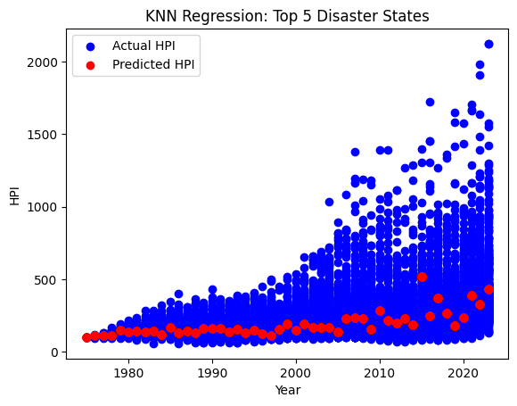

```python
# Assuming 'X_test' and 'y_pred' are already defined from the previous code
import matplotlib.pyplot as plt
plt.scatter(XTestKnn, yTestKnn, color='blue', label='Actual HPI')
plt.scatter(XTestKnn, yPredKnn, color='red', label='Predicted HPI')
plt.title("KNN Regression: Top 5 Disaster States")
plt.xlabel("Year")
plt.ylabel("HPI")
plt.legend()
plt.show()
```

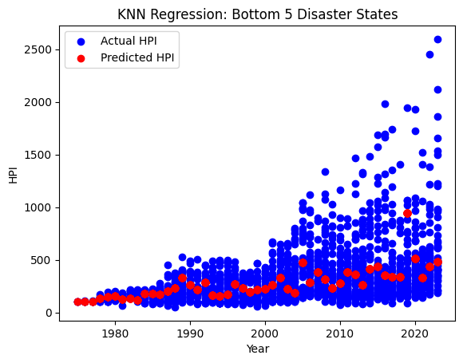

```python
# Plot predictions
plt.scatter(XTestKnn2, yTestKnn2, color='blue', label='Actual HPI')
plt.scatter(XTestKnn2, yPredKnn2, color='red', label='Predicted HPI')
plt.title("KNN Regression: Bottom 5 Disaster States")
plt.xlabel("Year")
plt.ylabel("HPI")
plt.legend()
plt.show()
```

## Predictions: K-Nearest Neighbors Regression

Based on our KNN regression model, the average HPI predicted for 2024 in the **top five disaster prone states** is approximately **432**. In the **bottom five disaster prone states** is approximately **482**.

A predicted HPI of 432 in the top 5 states suggests strong growth, while 482 in the bottom 5 states suggests even greater appreciation.

# Model Comparison: Linear Regression vs. K-Nearest Neighbors (KNN) Regression

Both models consistently predicted higher HPI values for states with fewer natural disasters, supporting our hypothesis that disaster exposure can negatively impact long term housing price growth. While Linear Regression provided a clearer explanation, KNN still helped validate the trend through an alternative method.